# exerc-suavizacao-exp

##### 1. A série tcm10y registra a taxa de retorno de mercado de tı́tulos do Tesouro dos EUA com maturidade constante de 10 anos.

> 1. Faça um gráfico da série e discuta suas caracterı́sticas. Para ter acesso à série, use os comandos

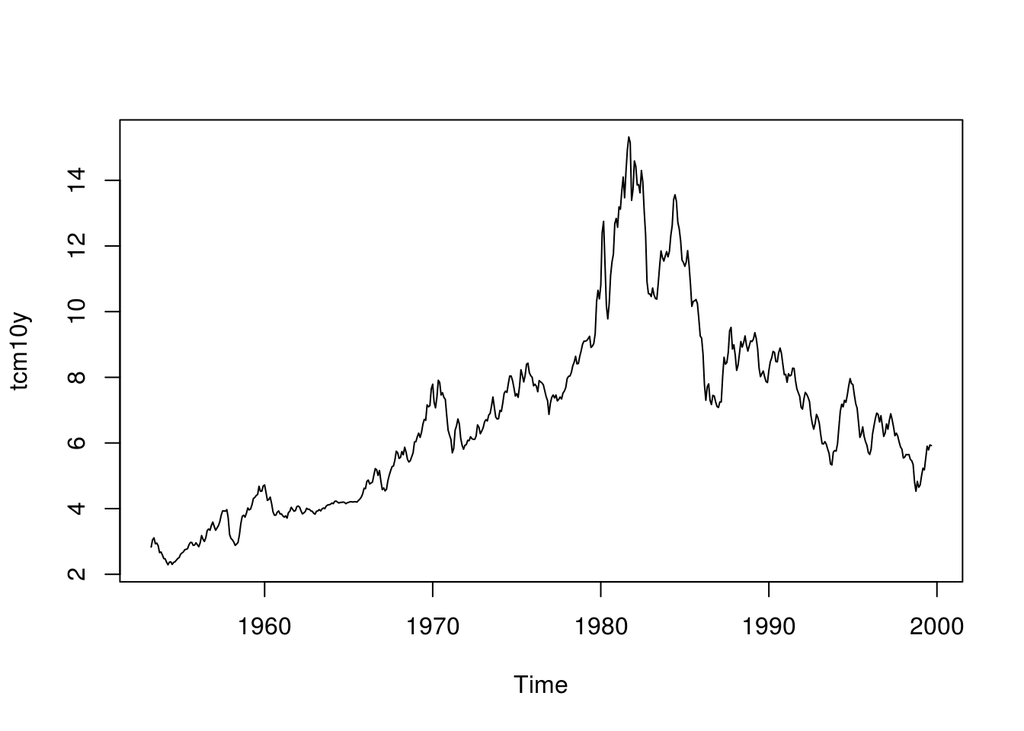

```r
plot(tcm10y)
```

A série inteira não tem um comportamento sazonal aparente, embora se isolarmos pequenas partes da série podemos ver uma espécie de comportamento sazonal.

Possui uma tendência não linear que sobe até o ano de (aproximadamente) 1982, após isso a tendência começa a cair.

Nenhum comportamento cíclico.

> 2. Divida a série em uma série de treinamento com 538 observações e uma série de testes com 20 observações.

```r
tcm10y.test <- window(tcm10y, start=c(1998, 2))
tcm10y.training <- window(tcm10y, end=c(1998,1))
```

> 3. Usando a série de treinamento, ajuste um modelo SES com α = 0,2. Faça um gráfico com o modelo ajustado sobreposto à série original, e comente sobre a adequação do modelo

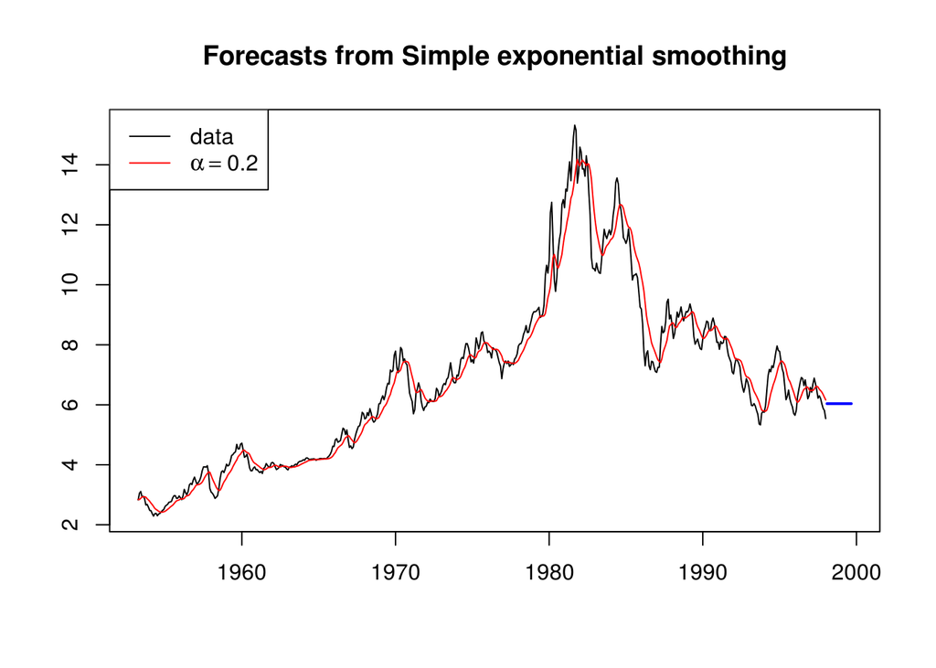

```r
tcm10y.training.ses1 <- ses(tcm10y.training, alpha=0.2, h=20)
plot(tcm10y.training.ses1, plot.conf=FALSE)
lines(fitted(tcm10y.training.ses1), col="red")

legend("topleft",lty=1, col=c(1,"red"), c("data", expression(alpha == 0.2)))
```

O modelo ses com $\alpha = 0.2$ se adequou bem a serie original.

> 4. Gere 20 previsões um passo à frente usando as observações da série de testes. Determine o maior e menor resı́duo, e calcule o RMSE para esse conjunto de previsões.

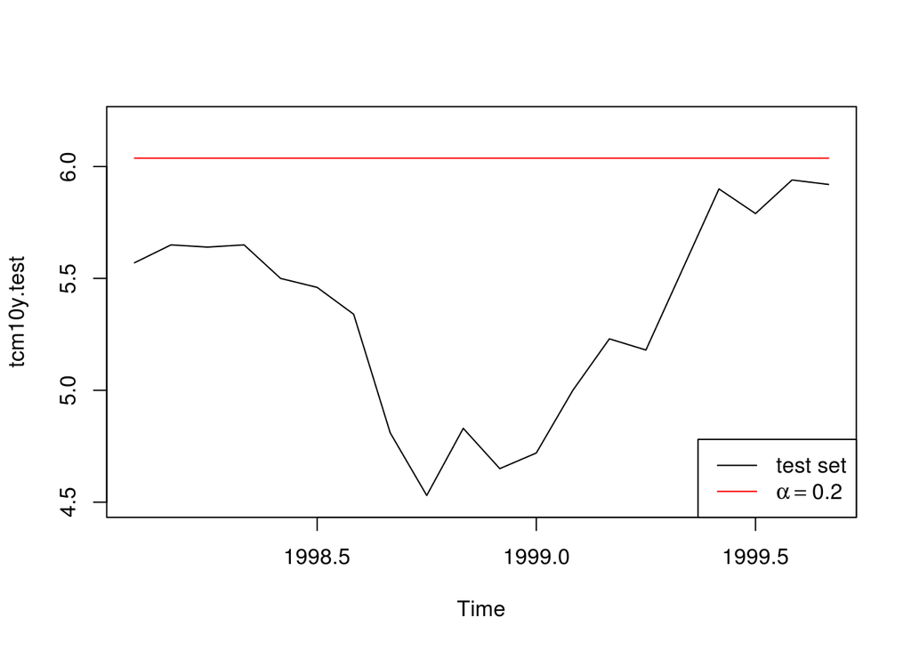

```r
plot(tcm10y.test, ylim=c(4.5, 6.2))
lines(tcm10y.training.ses1$mean, col="red")
legend("bottomright",lty=1, col=c(1,"red"), c("test set", expression(alpha == 0.2)))
```

```r
max(tcm10y.training.ses1$residuals)
```

```
## [1] 2.466973
```

```r
min(tcm10y.training.ses1$residuals)
```

```
## [1] -2.61774
```

```r
accuracy(tcm10y.training.ses1, tcm10y.test)
```

```
##                       ME      RMSE       MAE         MPE      MAPE
## Training set  0.02966374 0.5646659 0.3987033   0.2428158  5.656136
## Test set     -0.69510744 0.8216405 0.6951074 -13.8057428 13.805743
##                   MASE      ACF1 Theil's U
## Training set 0.4487096 0.8616166        NA
## Test set     0.7822896 0.8248005  3.879853
```